# Wormbiome pipeline Report

# Overview of your project

## General stat from metadata

You have submitted a metadata with 20 categories and you choosed to run stats on Strain

The following sample are in the metadata but not in the dataset: X97, X98, X99

The following sample are in the dataset but not in the metadata: X001, X002, X003, X004, X005, X006, X007, X008, X009, X010, X011, X012, X013, X014, X015, X016, X017, X018, X019, X020, X021, X022, X023, X024, X025, X026, X027, X028, X029, X030, X031, X032, X033, X034, X035, X036, X037, X038, X039, X040, X041, X042, X043, X044, X045, X046, X047, X048, X049, X050, X051, X052, X053, X054, X055, X056, X057, X058, X059, X060, X061, X062, X063, X064, X065, X066, X067, X068, X069, X070, X071, X072, X073, X074, X075, X076, X077, X078, X079, X080, X081, X082, X083, X084, X085, X086, X087, X088, X089, X090, X091, X092, X093, X094, X095, X096, X097, X098, X099, X121, X122, X123, X124, X125, X126, X127, X128, X129, X130, X131, X132, X133, X134, X135, X136, X137, X138, X139, X140, X141, X142, X143, X144, X145, X146, X147, X148, X149, X150, X151, X152, X153, X154, X155, X156, X157, X158, X159, X160, X161, X162, X163, X164, X165, X166, X167, X168, X169, X170, X171, X172, X173, X174, X175, X176, X177, X178, X179, X180, X182, X183, X184, X185, X186, X188, X189, X190, X191, X192, X193, X194, X195, X196, X197, X198, X199, X200, X201, X202, X203, X204, X205, X206, X207, X208, X209, X210, X211, X212, X213, X214, X215, X216, X217, X218, X219, X220, X221, X222, X223, X224, X225, X226, X227, X228, X229, X230, X231, X232, X233, X234, X235, X236, X237, X238, X239, X240, X241, X242, X243, X244, X245, X246, X247, X248, X249, X250, X251, X252, X253, X254, X255, X256, X257, X258, X259, X260, X261, X262, X263, X264, X265, X266, X267, X268, X269, X270, X271, X272, X273, X274, X275, X276, X277, X278, X279, X280, X281, X282, X283, X284, X285, X286, X287, X288, X289, X290, X291, X292, X293, X294, X295, X296, X297, X298, X299, X300, X301, X302, X303, X304, X305, X306, X307, X308, X309, X310, X311, X312, X313, X314, X315, X316, X317, X318, X319, X320, X321, X322, X323, X324, X325, X326, X327, X328, X329, X330, X331, X332, X333, X334, X335, X336, X337, X338, X339, X340, X341, X342, X343, X344, X345, X346, X347, X348, X349, X350, X351, X352, X353, X355, X356, X357, X358, X359, X360, X361, X362, X363, X364, X365, X366, X367, X368, X369, X370, X371, X372, X374, X375, X377, X378, X379, X380, X381, X382, X383, X384, X385, X386, X387, X389, X390, X393, X395, X396, X398, X402, X404, X405, X406, X407, X409, X410, X412, X413, X414, X416, X417, X418, X419, X420, X421, X422, X424, X425, X426, X428, X429, X430, X431, X434, X436, X437, X438, X440, X441, X442, X445, X446, X448, X449, X450, X452, X453, X454, X455, X457, X458, X460, X461, X462, X464, X465, X466, X467, X474

## The genomes

13 are not present in the database yet. Those are: JUb101, BIGb0211, BIGb0193, BIGb0186, BIGb0506, JUb30, BIGb0272, BIGb0167, JUb18, BIGb0117, JUb83, BIGb0281, BIGb0220

=====

The following ASV sequences have no count:

The following samples are empty:

Both empty ASV and Sample were removed from the rest of the analysis.

# Oveview of the ASV table

The ASV not mapping to any selected genomes represent 13.54% of the dataset.

```r
setwd(PWD)
```

[output not shown]

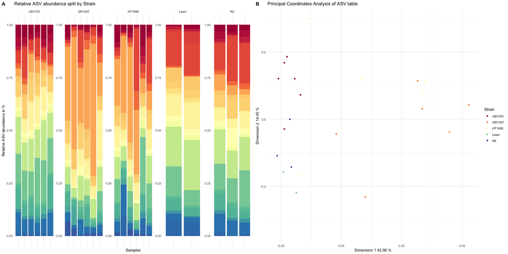

```r
Figure1<-ggpubr::ggarrange(ASV.barplot,ASV.PCoa, labels=c("A","B"))
ggsave(filename = paste(out.folder, "Figure1.png", sep=""),plot = Figure1, device = "png",width = 20, height = 10, dpi=72)
knitr::include_graphics(paste(out.folder, "Figure1.png",sep=""), dpi = 72)
```